# eBay Homework

1: That women bid higher than men 2: That bidders will pay more for a new item than an old one

To do that we will examine data from eBay auctions (and look at some prior literature). The dataset contains the results from auctions completed in 2008 for Apple 3rd Gen iPods (1GB).

Instructions:

1. Find, download, and read the following article: Ba, S., & Pavlou, P. A. (2002). Evidence of the effect of trust-building technology in electronic markets: Price premiums and buyer behavior. MIS Quarterly, 243-268.

Pay special attention to Study 2

2. Create an R Notebook Titled eBay Homework

3a. Read in the following eBay data:

```r
library(tidyverse)
exfile = "http://www.itk.ilstu.edu/faculty/jrwolf/ebay.csv"
df = read_csv(exfile)
head(df)
```

| Bids | Color | Price | BuyerFB | lnBuyerFB | SellerFB | lnSellerFB | ShipCost | GenderInd | New | Used | Cond | Gender |
| --- | --- | --- | --- | --- | --- | --- | --- | --- | --- | --- | --- | --- |
| 1 | White | 23.95 | 228 | 5.433722 | 15 | 2.708050 | 6.00 | 0 | 0 | 1 | Used | M |
| 1 | White | 11.00 | 911 | 6.815640 | 205 | 5.323010 | 4.80 | 0 | 0 | 1 | Used | M |
| 1 | White | 20.00 | 164 | 5.105945 | 85 | 4.442651 | 5.50 | 0 | 0 | 1 | Used | M |
| 1 | White | 25.00 | 7 | 2.079442 | 175 | 5.164786 | 10.00 | 0 | 0 | 1 | Used | M |
| 2 | White | 7.49 | 270 | 5.602119 | 4725 | 8.460623 | 7.95 | 0 | 0 | 1 | Used | M |
| 4 | White | 15.50 | 195 | 5.278115 | 26 | 3.258097 | 5.00 | 0 | 0 | 1 | Used | M |

# b. Examine the data (look at head and tail)

```r
head(df)
```

| Bids | Color | Price | BuyerFB | lnBuyerFB | SellerFB | lnSellerFB | ShipCost | GenderInd | New | Used | Cond | Gender |
| --- | --- | --- | --- | --- | --- | --- | --- | --- | --- | --- | --- | --- |
| 1 | White | 23.95 | 228 | 5.433722 | 15 | 2.708050 | 6.00 | 0 | 0 | 1 | Used | M |
| 1 | White | 11.00 | 911 | 6.815640 | 205 | 5.323010 | 4.80 | 0 | 0 | 1 | Used | M |
| 1 | White | 20.00 | 164 | 5.105945 | 85 | 4.442651 | 5.50 | 0 | 0 | 1 | Used | M |
| 1 | White | 25.00 | 7 | 2.079442 | 175 | 5.164786 | 10.00 | 0 | 0 | 1 | Used | M |
| 2 | White | 7.49 | 270 | 5.602119 | 4725 | 8.460623 | 7.95 | 0 | 0 | 1 | Used | M |
| 4 | White | 15.50 | 195 | 5.278115 | 26 | 3.258097 | 5.00 | 0 | 0 | 1 | Used | M |

```r
tail(df)
```

| Bids | Color | Price | BuyerFB | lnBuyerFB | SellerFB | lnSellerFB | ShipCost | GenderInd | New | Used | Cond | Gender |
| --- | --- | --- | --- | --- | --- | --- | --- | --- | --- | --- | --- | --- |
| 26 | Blue | 36.02 | 774 | 6.652863 | 23 | 3.1354942 | 8.98 | 0 | 1 | 0 | New | M |
| 26 | Blue | 35.50 | 9 | 2.302585 | 22396 | 10.0166376 | 6.30 | 1 | 1 | 0 | New | F |
| 26 | Blue | 48.00 | 53 | 3.988984 | 922 | 6.8265452 | 0.00 | 1 | 1 | 0 | New | F |
| 30 | Blue | 51.00 | 7 | 2.079442 | 52 | 3.9512437 | 0.00 | 1 | 1 | 0 | New | F |
| 34 | Blue | 40.00 | 8 | 2.197225 | 737 | 6.6025879 | 0.00 | 1 | 1 | 0 | New | F |
| 42 | Blue | 46.00 | 31 | 3.465736 | 2 | 0.6931472 | 59.57 | 0 | 1 | 0 | New | M |

# c. Examine the structure (str) of the data

```r
str(df)
```

```
spec_tbl_df [1,083 x 13] (S3: spec_tbl_df/tbl_df/tbl/data.frame)
 $ Bids      : num [1:1083] 1 1 1 1 2 4 4 5 7 8 ...
 $ Color     : chr [1:1083] "White" "White" "White" "White" ...
 $ Price     : num [1:1083] 23.95 11 20 25 7.49 ...
 $ BuyerFB   : num [1:1083] 228 911 164 7 270 195 131 48 90 32 ...
 $ lnBuyerFB : num [1:1083] 5.43 6.82 5.11 2.08 5.6 ...
 $ SellerFB  : num [1:1083] 15 205 85 175 4725 ...
 $ lnSellerFB: num [1:1083] 2.71 5.32 4.44 5.16 8.46 ...
 $ ShipCost  : num [1:1083] 6 4.8 5.5 10 7.95 5 5.95 5 4.5 12 ...
 $ GenderInd : num [1:1083] 0 0 0 0 0 0 1 1 1 0 ...
 $ New       : num [1:1083] 0 0 0 0 0 0 0 0 0 0 ...
 $ Used      : num [1:1083] 1 1 1 1 1 1 1 1 1 1 ...
 $ Cond      : chr [1:1083] "Used" "Used" "Used" "Used" ...
 $ Gender    : chr [1:1083] "M" "M" "M" "M" ...
 - attr(*, "spec")=
  .. cols(
  ..   Bids = col_double(),
  ..   Color = col_character(),
  ..   Price = col_double(),
  ..   BuyerFB = col_double(),
  ..   lnBuyerFB = col_double(),
  ..   SellerFB = col_double(),
  ..   lnSellerFB = col_double(),
  ..   ShipCost = col_double(),
  ..   GenderInd = col_double(),
  ..   New = col_double(),
  ..   Used = col_double(),
  ..   Cond = col_character(),
  ..   Gender = col_character()
  .. )
 - attr(*, "problems")=<externalptr>
```

# d1. Find the Mean (mean) and Standard Deviation (sd) by old/new of Price

```r
oldPrices = df %>%
  filter(Used == 1) %>%
  summarize(meanUsed = mean(Price, na.rm = TRUE), sdUsed = sd(Price, na.rm = TRUE))
oldPrices
```

| meanUsed | sdUsed |
| --- | --- |
| 31.40495 | 11.18313 |

```r
newPrices = df %>%
  filter(New == 1) %>%
  summarize(meanNew = mean(Price, na.rm = TRUE), sdNew = sd(Price, na.rm = TRUE))
newPrices
```

| meanNew | sdNew |
| --- | --- |
| 42.79198 | 8.770916 |

```r
NA
NA
```

# d2. Find the Mean (mean) and Standard Deviation (sd) by male/female of Price

```r
maleBuys = df %>%
  filter(Gender == "M") %>%
  summarize(meanUsed = mean(Price, na.rm = TRUE), sdUsed = sd(Price, na.rm = TRUE))
maleBuys
```

| meanUsed | sdUsed |
| --- | --- |
| 37.83654 | 12.20783 |

```r
femaleBuys = df %>%
  filter(Gender == "F") %>%
  summarize(meanNew = mean(Price, na.rm = TRUE), sdNew = sd(Price, na.rm = TRUE))
femaleBuys
```

| meanNew | sdNew |
| --- | --- |
| 38.48699 | 10.33858 |

# e1. Create a boxplot of Price (by old/new )

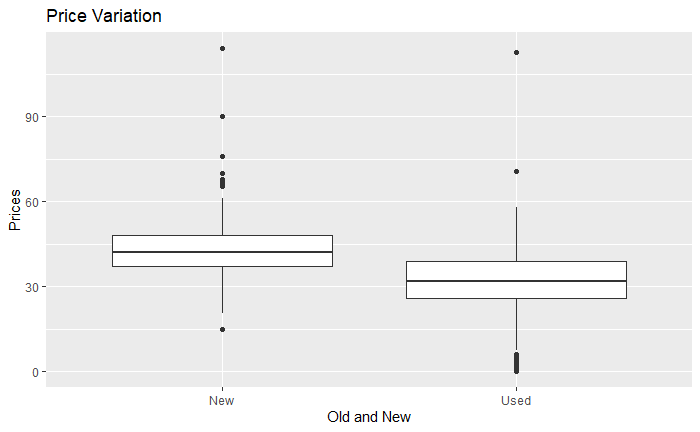

```r
df %>%
  ggplot(aes(x = Cond, y = Price)) +
  labs(title = "Price Variation", y = "Prices", x = "Old and New") +
  geom_boxplot()
```

# e2. Create a boxplot of Price (by male/female )

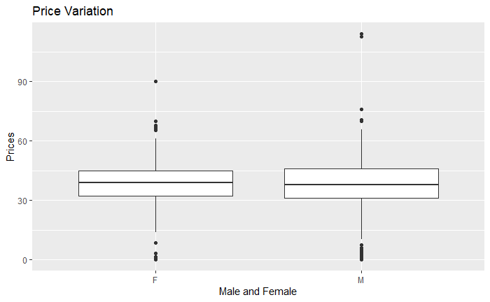

```r
df %>%
  ggplot(aes(x = Gender, y = Price)) +
  labs(title = "Price Variation", y = "Prices", x = "Male and Female") +
  geom_boxplot()
```

# f. Create a histogram of Price (by color)

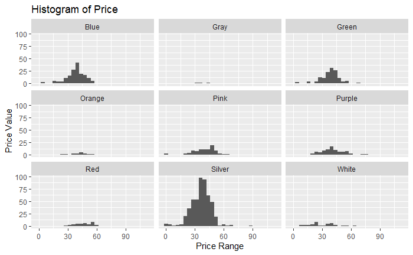

# g1. Run a t-test on Price (by old/new)

```r
t.test(Price ~ Cond, data = df)
```

```
    Welch Two Sample t-test

data:  Price by Cond
t = 17.918, df = 790.57, p-value < 2.2e-16
alternative hypothesis: true difference in means between group New and group Used is not equal to 0
95 percent confidence interval:
 10.13953 12.63451
sample estimates:
 mean in group New mean in group Used
          42.79198           31.40495
```

# g2. Run a t-test on Price (by male/female)

```r
t.test(Price ~ Gender, data = df)
```

```
    Welch Two Sample t-test

data:  Price by Gender
t = 0.94515, df = 1044, p-value = 0.3448
alternative hypothesis: true difference in means between group F and group M is not equal to 0
95 percent confidence interval:
 -0.6999539  2.0008479
sample estimates:
mean in group F mean in group M
       38.48699        37.83654
```

# h. report your findings for both t-tests using APA format

There is a big statistical difference, when we check the Condition of the product whether it is new item price (M = 42.79) compared to the Old item price(M = 31.40), t(790) = 17.9, p < 2.2e-16.

On average, Women spent more on items (M = 38.49) compared to Men(M = 37.83) this difference was not at all significant, t(1044) = 0.95, p = 0.34.